# 1. Project Overview

```python
# Having downloaded the 21 files, let us now use pandas to read and concatenate them
# We expect a total of 400 entries after the concatenation.

soil_photos_df = []

# define the download pathway
download_path = os.path.join(BASE_DIR, "scraped_datasets")

for i in range(1, 21):
    file = os.path.join(download_path, f"K{i}.csv")

    if os.path.exists(file):
        df = pd.read_csv(file)
        soil_photos_df.append(df)
    else:
        print(f"Missing file: {file}")

combined_soil_photos_df = pd.concat(soil_photos_df, ignore_index=True)

print(combined_soil_photos_df.shape)

# Saving the combined dataset to a new CSV file
combined_soil_photos_df.to_csv("datasets/combined_soil_photos.csv", index=False)
```

```
(400, 5)
```

```python
# Loading our combined dataframe with soil images
combined_soil_photos_df = pd.read_csv('datasets/combined_soil_photos.csv')

# Confirming the data has loaded
print(f"Dataset length: {len(combined_soil_photos_df)}")
combined_soil_photos_df.head(2)
```

```
Dataset length: 400
```

|  | plot_code | country_name | horizontal_down_photo | horizontal_up_photo | vertical_photo |
| --- | --- | --- | --- | --- | --- |
| 0 | KE061-1-1 | Kenya | <a href="data:… | <a href="data:… | <a href="data:… |
| 1 | KE061-2-3 | Kenya | <a href="data:… | <a href="data:… | <a href="data:… |

- The images are encoded in a string that is a data URL (Data URI) containing an image encoded in Base64.

Working with the above format is associated with the following:

- Large file size overhead → Base64 encoding increases size by ~33%, making storage and transfer less efficient compared to normal image files
- Memory usage → Entire image must be loaded into memory as a string before decoding, which can be heavy for large datasets or many images
- Slower processing → Requires encoding/decoding steps, adding CPU overhead when reading or writing images
- Harder to manage → Images are embedded in text, so you can’t easily preview, edit, or organize them like normal .png/.jpg files.

Secondly, we noted by viewing the images that the vertical photos all have noise data including:

- Hand tools used by the farmers.
- Holes dug by the farmers.

These may lead to:

- Spurious feature learning (shortcut bias) - The network may latch onto tools or hole shapes instead of soil properties. This is a classic case of models exploiting Spurious Correlation, where non-causal cues become predictive simply because they co-occur with labels.
- Reduced generalization. If test images don’t contain tools/holes (or contain different ones), performance drops. The model will not have learned soil characteristics; it would have instead learnt context artifacts.

We noted however that the horizontal_up photos have minimal noise and still capture both crop and soil characteristics. We will therefore:

1. Drop the horizontal_down (since it is a repetition of the horizontal_up and naturally, photos are taken in a horizontal up manner) as well as vertical photos (due to noise effect).
2. Convert the maintained 'horizontal_up' photos to arrays that will make it easy to analyze the dataset and machine learning.
3. Store the file as a new csv file - 'soil_photos'

```python
# Dropping the horizontal_down, vertical photos and country name (since all rows represent the same country).

combined_soil_photos_df = combined_soil_photos_df.drop(['horizontal_down_photo', 'vertical_photo', 'country_name'], axis=1)
```

```python
# Confirming that the columns have been dropped
combined_soil_photos_df.columns
```

```
Index(['plot_code', 'horizontal_up_photo'], dtype='object')
```

```python
# Creating a function that utilizes a for loop to convert our remaining 'horizontal_up_photo' to numpy array data.

def images_to_numpy(df, column_name, target_size=(224, 224)):
    image_arrays = []

    for index, row in df.iterrows():
        b64_string = row[column_name]

        try:
            if not isinstance(b64_string, str):
                continue

            # Remove data URL prefix if present
            if "," in b64_string[:50]:
                b64_string = b64_string.split(",", 1)[1]

            # Decode base64
            img_bytes = base64.b64decode(b64_string)

            # Load image
            img = Image.open(BytesIO(img_bytes)).convert("RGB")

            # Resize
            img = img.resize(target_size)

            # Convert to array
            img_array = np.array(img)

            image_arrays.append(img_array)

        except Exception as e:
            print(f"Skipping row {index} due to error: {e}")

    if len(image_arrays) == 0:
        return None

    return np.stack(image_arrays)
```

```python
# Converting our 'horizontal_up_photos' to numpy arrays.
soil_photos_arrays = images_to_numpy(
    combined_soil_photos_df,
    "horizontal_up_photo",
    target_size=(224, 224)
)
```

```
Skipping row 368 due to error: cannot identify image file <_io.BytesIO object at 0x000001A70289D1D0>
Skipping row 369 due to error: cannot identify image file <_io.BytesIO object at 0x000001A70289D180>
Skipping row 378 due to error: cannot identify image file <_io.BytesIO object at 0x000001A70289D1D0>
Skipping row 379 due to error: cannot identify image file <_io.BytesIO object at 0x000001A702AC01D0>
```

```python
# Confirming the length of our arrays.
len(soil_photos_arrays) # 4 conversions failed to take place, therefore from the initial 400, we now have 396 soil images.
```

```
396
```

```python
# Adding our photos arrays to the combined_soil_photos_df
combined_soil_photos_df = combined_soil_photos_df.iloc[:len(soil_photos_arrays)].copy()
combined_soil_photos_df["image_array"] = list(soil_photos_arrays)
```

```python
# Confirming the column 'image array' has been added to our column list.
combined_soil_photos_df.columns
```

```
Index(['plot_code', 'horizontal_up_photo', 'image_array'], dtype='object')
```

```python
# Looking at the entries in the new column 'image_array'

combined_soil_photos_df.head()
```

|  | plot_code | horizontal_up_photo | image_array |
| --- | --- | --- | --- |
| 0 | KE061-1-1 | <a href="data:… | [[[255, 255, 255], [254, 254, 254], [253, 253,... |
| 1 | KE061-2-3 | <a href="data:… | [[[94, 132, 194], [95, 133, 195], [96, 134, 19... |
| 2 | KE061-1-2 | <a href="data:… | [[[199, 206, 218], [202, 209, 220], [205, 213,... |
| 3 | KE061-3-1 | <a href="data:… | [[[232, 230, 238], [230, 230, 240], [228, 231,... |
| 4 | KE061-4-1 | <a href="data:… | [[[224, 231, 241], [226, 233, 243], [227, 234,... |

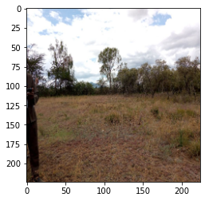

```python
# Confirming that the conversion from base 64 to numpy arrays happened without errors.
# Let us look at the first image using matplotlib

plt.imshow(combined_soil_photos_df['image_array'][0])
plt.show()
```

```python
# Now that we have a column of the images of the soils in a numpy array, we can drop the base 64 'horizontal_up_photo' column

combined_soil_photos_df = combined_soil_photos_df.drop('horizontal_up_photo', axis = 1)

# Confirming that we have dropped the column
combined_soil_photos_df.columns
```

```
Index(['plot_code', 'image_array'], dtype='object')
```

### Missing Values

```python
# Checking for missing entries

combined_soil_photos_df.isna().sum() # There are no missing values
```

```
plot_code      0
image_array    0
dtype: int64
```

```python
# Describe the combined_soil_photos df

combined_soil_photos_df.info()
```

```
<class 'pandas.core.frame.DataFrame'>
RangeIndex: 396 entries, 0 to 395
Data columns (total 2 columns):
 #   Column       Non-Null Count  Dtype
---  ------       --------------  -----
 0   plot_code    396 non-null    object
 1   image_array  396 non-null    object
dtypes: object(2)
memory usage: 6.3+ KB
```

```python
# Saving the CSV file of the soil photos
combined_soil_photos_df.to_csv("datasets/cleaned_soil_photos.csv", index=False)
```

From the output above on summary statistics:

- All our columns are of the 'object' data type.
- There are no missing entries

## Combined dataset having both physical soil attributes and soil images

To have an algorithm that incorporates both physical soil attributes and soil images, we will incorporate our cleaned soil_df (which contains the dataframe with the cleaned physical soil attributes) and the combined soil_df (which contains the Cleaned Kenyan Dataset with images as numpy arrays).

- We expect an eventual dataset that contains only Kenyan Data.
- This will be used solely for soil image classification.

```python
# We will merge the datasets using pandas.merge

merged_physical_and_images_df = pd.merge(combined_soil_photos_df, cleaned_soil_df, on="plot_code", how="inner")

# Confirming the merger by confirming the length of the dataset. We expect 396 entries

len(merged_physical_and_images_df)
```

```
87
```

```python
# Confirming the columns of the merged dataset
merged_physical_and_images_df.columns
```

```
Index(['plot_code', 'image_array', 'country_code', 'survey_date', 'altitude',
       'longitude', 'latitude', 'tsu_id', 'plot_id', 'country_name',
       'sign_of_erosion', 'srf_salt', 'srf_crust', 'crsfrgab', 'srf_stone',
       'lndform', 'slope_class', 'bare_soil', 'main_land_use', 'life_forms',
       'crop_type', 'field_size', 'field_distribution_pattern',
       'ploughing_sign', 'ploughing_direction', 'tillage_mode',
       'input_crop_residue', 'input_green_manure', 'input_animal_manure',
       'input_inorganic', 'water_supply', 'grazing_sign_present',
       'grazing_sign_infrastructure', 'grazing_sign_droppings',
       'grazing_sign_grass', 'overgrazing_sign_bare', 'overgrazing_sign_dung',
       'overgrazing_sign_deforest'],
      dtype='object')
```

```python
# Confirming that the datasets have been merged.
merged_physical_and_images_df.head()
```

|  | plot_code | image_array | country_code | survey_date | altitude | longitude | latitude | tsu_id | plot_id | country_name | ... | input_animal_manure | input_inorganic | water_supply | grazing_sign_present | grazing_sign_infrastructure | grazing_sign_droppings | grazing_sign_grass | overgrazing_sign_bare | overgrazing_sign_dung | overgrazing_sign_deforest |
| --- | --- | --- | --- | --- | --- | --- | --- | --- | --- | --- | --- | --- | --- | --- | --- | --- | --- | --- | --- | --- | --- |
| 0 | KE066-4-2 | [[[81, 134, 186], [82, 135, 187], [82, 135, 18... | KE | 2023/05/17 | 1143 | 37.614426 | -0.974514 | 979535400101402 | 3226 | Kenya | ... | Yes | Yes | Rainfed | No | No | No | No | No | No | No |
| 1 | KE078-5-1 | [[[160, 188, 212], [160, 188, 212], [160, 188,... | KE | 2023/05/19 | 1574 | 36.966668 | -1.537273 | 993336100800901 | 3238 | Kenya | ... | Yes | No | Rainfed | No | No | No | No | No | No | No |
| 2 | KE087-1-1 | [[[237, 240, 247], [239, 242, 249], [238, 241,... | KE | 2023/06/13 | 914 | 37.841510 | -2.231378 | 1010262302001401 | 4721 | Kenya | ... | Yes | No | Rainfed | No | No | No | No | No | No | No |
| 3 | KE087-2-1 | [[[239, 239, 247], [245, 245, 253], [247, 247,... | KE | 2023/06/13 | 919 | 37.830962 | -2.225831 | 1010262301400301 | 4723 | Kenya | ... | Yes | No | Rainfed | No | No | No | No | No | No | No |
| 4 | KE083-2-1 | [[[251, 251, 253], [224, 224, 225], [212, 212,... | KE | 2023/06/14 | 992 | 37.774499 | -1.954665 | 1003582501200301 | 4725 | Kenya | ... | Yes | No | Rainfed | No | No | No | No | No | No | No |

5 rows × 38 columns

- The limitation of the 87 samples in the combined Kenyan dataset (covering both physical attributes and soil data) is due to the small sample size in cleaned_soil_df.
- Therefore, this combined dataset will only be used to train the soil image classifier for the dashboard, making it more specific to the Kenyan context.
- However, the broader physical_soil_attributes dataset from soil_df will be used to train a separate model for general crop type prediction across Africa.

```python
# Saving the merged_physical_and_images_df to a new CSV file
merged_physical_and_images_df.to_csv("datasets/merged_physical_and_images_df.csv", index=False)
```

# 5.0 Exploratory Data Analysis

In this section we will analyse the following:

1. Which physical soil attributes (slope class, landform, erosion type, grazing signs) are the strongest predictors of crop type?
2. Which land management practices (irrigation mode, manure application, ploughing direction, tillage mode, ploughing sign) have the greatest influence on crop type selection?
3. How do grazing intensity indicators (overgrazing signs, bare soil exposure, dung presence) affect the suitability and prediction of crop types?
4. How does geographical location (latitude, longitude and altitude) influence the crop type grown?

## 5.1 General Analysis

```python
# We will start by dropping the plot_code, latitude, longitude, country_name, country_code, Survey_date, altitude, plot_id and tsu_id columns since they are identifiers.

cleaned_soil_df_columns_to_remove = ['plot_code', 'latitude', 'longitude', 'country_name', 'country_code', 'survey_date', 'altitude', 'plot_id', 'tsu_id']

# We will create a variable called cleaned_soil_df_analysis that will contain the cleaned_soil_df dataset without the identifier columns.
cleaned_soil_df_analysis = cleaned_soil_df.drop(columns=cleaned_soil_df_columns_to_remove)
```

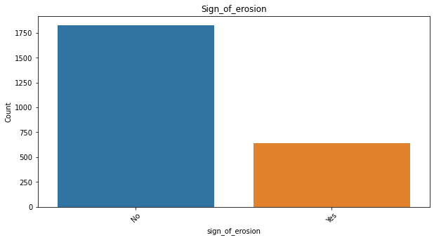

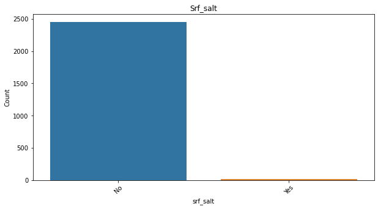

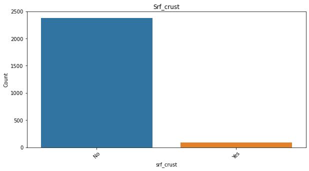

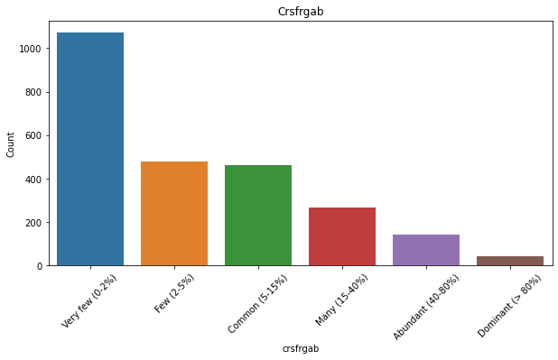

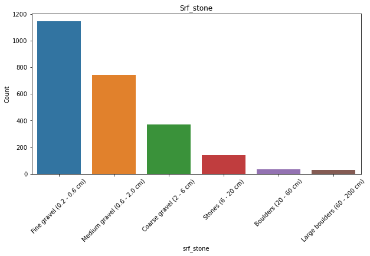

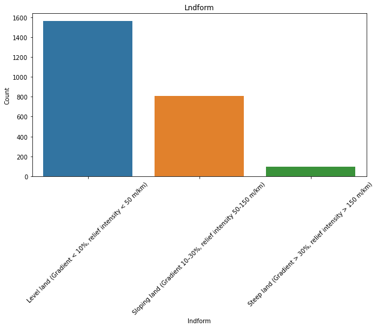

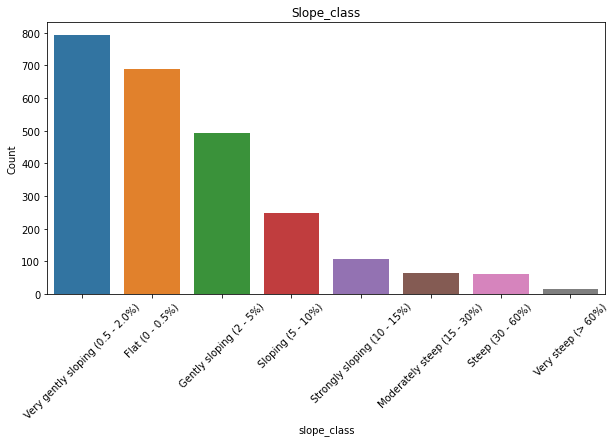

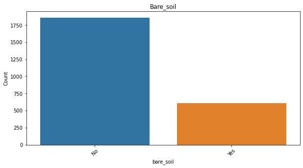

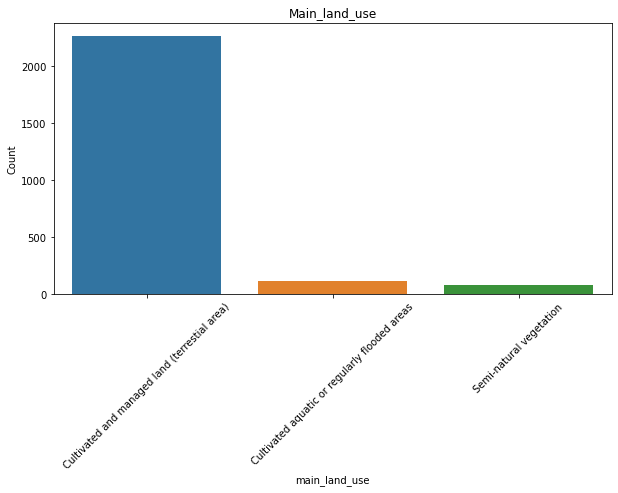

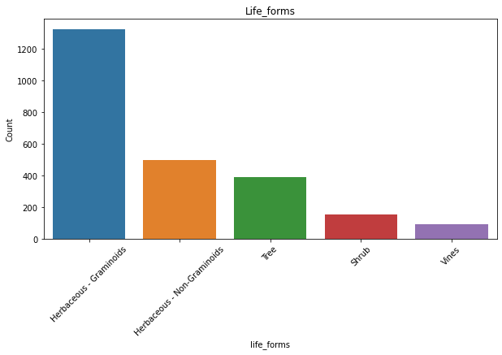

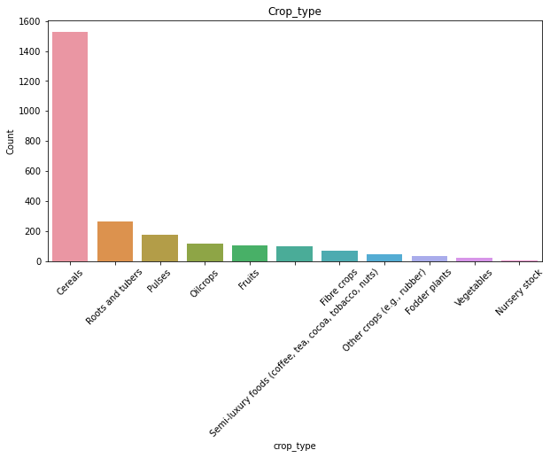

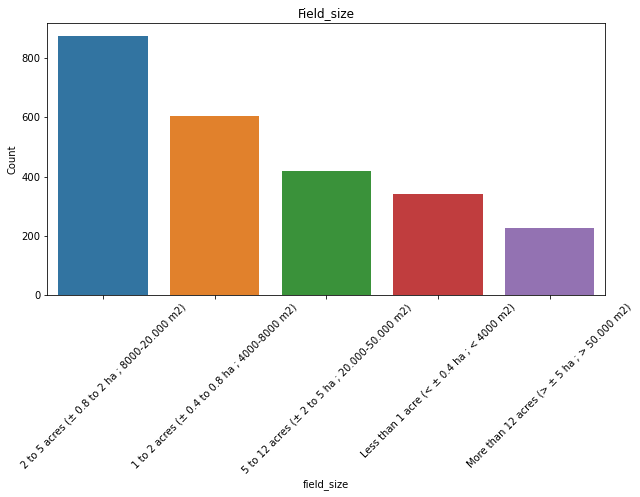

[16 more figures not shown]

```python
# We will create a variable containing the column of cleaned_soil_df_analysis to run a general analysis on our features.
cleaned_soil_df_analysis_columns = cleaned_soil_df_analysis.columns

# We will use a for loop to give a generate value_counts of the remaining columns and illustrate them using matplotlib.

for column in cleaned_soil_df_analysis_columns:
    value_counts = cleaned_soil_df_analysis[column].value_counts()
    plt.figure(figsize=(10, 5))
    sns.barplot(x=value_counts.index, y=value_counts.values)
    plt.title(f'{column.capitalize()}')
    plt.xlabel(column)
    plt.ylabel('Count')
    plt.xticks(rotation=45)
    plt.show()
```

### Summary Findings.

#### Grazing Intensity Indicators

- Most land did not show signs of grazing (1600 vs 800).
- Neither did they have any grazing infrastructure (2100 vs 450).
- They also did not have grazing sign droppings (1750 vs 750).
- And did not have any grazing grass (1750 vs 750).
- Most land did not show signs of overgrazing deforestation (2100 vs 400).

### 5.2 - 5.5 Determining the strongest attribute predictors of crop type

In order to do this, we will:

1. Index the columns of specific attribute predictors (Geometric, Physical, Land Mangement Practices and Grazing Intensity Indicators)
- We will be using the soil_df in which we dropped columns that had null entries: 'obstruct_lyr', 'depth_restriction_cause', 'rill_erosion', 'gully_erosion', 'mass_erosion', 'stone_pedestals', 'stone_pavement', 'wind_erosion', 'slope_position', 'slope_pathway', 'tree_rating_15m_above', 'tree_rating_3m_15m', 'shrub_rating', 'herbaceous_rating'.
1. We will name the variables of the above by the abbreviations of the classes of the attribute predictors.
2. We will group the expected four variables and name them as attribute predictors.
3. We will then use a for loop to loop over the individual predictors and apply Lasso style regularisation for classification so that less useful variables’ coefficients are reduced to exactly zero.
4. This way, we will have carried out feature selection and will have identified the most important features per attribute class.

```python
# Defining the columns that make up different attributes.
# 1. Identifiers and geographical attributes
geo_cols = ["altitude", "longitude", "latitude", "tsu_id", "country_name"]
geo_df = soil_df[geo_cols]

# 2. Physical soil attributes
soil_cols = ["sign_of_erosion","srf_salt", "srf_crust", "crsfrgab", "srf_stone",
    "lndform", "slope_class", "bare_soil", "main_land_use",
    "life_forms", "field_size", "field_distribution_pattern"]
phyc_soil_df = soil_df[soil_cols]

# 3. Land management practices
management_cols = ["ploughing_sign", "ploughing_direction", "tillage_mode",
    "input_crop_residue", "input_green_manure",
    "input_animal_manure", "input_inorganic",
    "water_supply"]
management_df = soil_df[management_cols]

# 4. Grazing intensity indicators
grazing_cols = ["grazing_sign_present", "grazing_sign_infrastructure",
    "grazing_sign_droppings", "grazing_sign_grass",
    "overgrazing_sign_bare", "overgrazing_sign_dung",
    "overgrazing_sign_deforest"]
grazing_df = soil_df[grazing_cols]
```

```python
# Combining the above four sub dataframes into one dataframe for analysis and feature selection using logistic regression with L1 regularization for predicting crop type.
dfs = {"geo": geo_df,
    "physical_soil": phyc_soil_df,
    "management": management_df,
    "grazing": grazing_df}
```

```python
# Using logistic regression and Lasso type regularization to perform feature selection.

results = {}

for name, df in dfs.items():

    # Drop missing rows
    X = df.dropna()

    # Encode categorical variables
    X = pd.get_dummies(X, drop_first=True)

    # Align target
    y = soil_df["crop_type"]

    # Model: L1 regularization (Lasso-style)
    model = Pipeline([
        ("scaler", StandardScaler()),
        ("logreg", LogisticRegression(
            penalty="l1",
            solver="saga",
            max_iter=5000,
            C=0.1   # smaller = stronger feature selection
        ))
    ])

    model.fit(X, y)

    # Extract coefficients
    coefs = model.named_steps["logreg"].coef_

    # Convert to DataFrame (handles multiclass)
    coef_df = pd.DataFrame(coefs, columns=X.columns)

    # Select features with any non-zero coefficient
    selected_features = coef_df.loc[:, (coef_df != 0).any(axis=0)]

    # Optional: rank by importance (magnitude)
    importance = selected_features.abs().max().sort_values(ascending=False)

    results[name] = importance

    print(f"\n{name.upper()} Most Important Features:")
    print(importance.head(5))
```

```
GEO Most Important Features:
country_name_Ghana      0.523797
country_name_Tunisia    0.490569
country_name_Benin      0.436252
country_name_Morocco    0.410489
country_name_Angola     0.396993
dtype: float64

PHYSICAL_SOIL Most Important Features:
life_forms_Herbaceous - Non-Graminoids                         0.792202
life_forms_Tree                                                0.725035
life_forms_Vines                                               0.708796
life_forms_Shrub                                               0.654813
main_land_use_Cultivated aquatic or regularly flooded areas    0.499398
dtype: float64

MANAGEMENT Most Important Features:
tillage_mode_Manual (hoe)                                                               0.679006
water_supply_Rainfed                                                                    0.522052
tillage_mode_Mechanical (tractor)                                                       0.451256
ploughing_sign_Signs of field recently tilled: presence of prominent ridges or heaps    0.357121
input_animal_manure_Yes                                                                 0.335185
dtype: float64

GRAZING Most Important Features:
grazing_sign_grass_Yes             0.541704
grazing_sign_infrastructure_Yes    0.534966
grazing_sign_present_Yes           0.355756
grazing_sign_droppings_Yes         0.319056
overgrazing_sign_dung_Yes          0.153967
dtype: float64
```

### Most important Geographical features

- Country location plays a strong role in predicting crop type.
- The most influential countries are:
  - **Ghana** (0.524)
  - **Tunisia** (0.491)
  - **Benin** (0.436)
  - **Morocco** (0.410)
  - **Angola** (0.397)

### Most important Physical Soil features

- Vegetation and land cover characteristics are the strongest predictors within soil attributes.
- Key features include:
  - **Herbaceous (Non-Graminoids)** (0.792)
  - **Tree-based systems** (0.725)
  - **Vines** (0.709)
  - **Shrubs** (0.655)
  - **Cultivated aquatic or regularly flooded areas** (0.499)

### Most important Management features

- Farming practices significantly influence crop type selection.
- The most important practices are:
  - **Manual tillage (hoe)** (0.679)
  - **Rainfed water supply** (0.522)
  - **Mechanical tillage (tractor)** (0.451)
  - **Signs of recently tilled fields (ridges/heaps)** (0.357)
  - **Use of animal manure** (0.335)

### Most important Grazing Sign features

- Grazing activity indicators also contribute to crop type prediction.
- Key indicators include:
  - **Grass grazing present** (0.542)
  - **Grazing infrastructure present** (0.535)
  - **General grazing presence** (0.356)
  - **Animal droppings present** (0.319)
  - **Dung-related overgrazing signs** (0.154)

### 5.6 Determining the relation between physical attributes and crops grown.

```python
# Using a for loop to index into the different physical soil columns

for column in soil_cols:
    print(f"\n Percentage Breakdown: Crop Type vs {column}")

    # Normalize='index' gives the proportion (0.0 to 1.0) for each crop row
    # Multiply by 100 to convert it into a readable percentage (0% to 100%)
    ctab_pct = pd.crosstab(soil_df['crop_type'], soil_df[column], normalize='index') * 100

    # Round to 2 decimal places so the tables are neat and easy to read
    ctab_pct = ctab_pct.round(2)

    display(ctab_pct)
```

```
 Percentage Breakdown: Crop Type vs sign_of_erosion
```

| sign_of_erosion crop_type | No | Yes |
| --- | --- | --- |
| Cereals | 73.08 | 26.92 |
| Fibre crops | 60.00 | 40.00 |
| Fodder plants | 88.24 | 11.76 |
| Fruits | 86.54 | 13.46 |
| Nursery stock | 100.00 | 0.00 |
| Oilcrops | 62.18 | 37.82 |
| Other crops (e.g., rubber) | 88.64 | 11.36 |
| Pulses | 62.29 | 37.71 |
| Roots and tubers | 82.33 | 17.67 |
| Semi-luxury foods (coffee, tea, cocoa, tobacco, nuts) | 86.73 | 13.27 |
| Vegetables | 76.92 | 23.08 |

```
 Percentage Breakdown: Crop Type vs srf_salt
```

| srf_salt crop_type | No | Yes |
| --- | --- | --- |
| Cereals | 99.48 | 0.52 |
| Fibre crops | 100.00 | 0.00 |
| Fodder plants | 100.00 | 0.00 |
| Fruits | 96.15 | 3.85 |
| Nursery stock | 100.00 | 0.00 |
| Oilcrops | 100.00 | 0.00 |
| Other crops (e.g., rubber) | 100.00 | 0.00 |
| Pulses | 99.43 | 0.57 |
| Roots and tubers | 100.00 | 0.00 |
| Semi-luxury foods (coffee, tea, cocoa, tobacco, nuts) | 100.00 | 0.00 |
| Vegetables | 100.00 | 0.00 |

```
 Percentage Breakdown: Crop Type vs srf_crust
```

| srf_crust crop_type | No | Yes |
| --- | --- | --- |
| Cereals | 96.33 | 3.67 |
| Fibre crops | 100.00 | 0.00 |
| Fodder plants | 97.06 | 2.94 |
| Fruits | 96.15 | 3.85 |
| Nursery stock | 100.00 | 0.00 |
| Oilcrops | 94.12 | 5.88 |
| Other crops (e.g., rubber) | 100.00 | 0.00 |
| Pulses | 93.71 | 6.29 |
| Roots and tubers | 97.74 | 2.26 |
| Semi-luxury foods (coffee, tea, cocoa, tobacco, nuts) | 100.00 | 0.00 |
| Vegetables | 96.15 | 3.85 |

```
 Percentage Breakdown: Crop Type vs crsfrgab
```

| crsfrgab crop_type | Abundant (40-80%) | Common (5-15%) | Dominant (> 80%) | Few (2-5%) | Many (15-40%) | Very few (0-2%) |
| --- | --- | --- | --- | --- | --- | --- |
| Cereals | 5.44 | 16.76 | 1.38 | 18.99 | 10.67 | 46.76 |
| Fibre crops | 8.57 | 15.71 | 5.71 | 25.71 | 5.71 | 38.57 |
| Fodder plants | 0.00 | 14.71 | 0.00 | 20.59 | 11.76 | 52.94 |
| Fruits | 2.88 | 21.15 | 7.69 | 20.19 | 11.54 | 36.54 |
| Nursery stock | 0.00 | 0.00 | 0.00 | 25.00 | 0.00 | 75.00 |
| Oilcrops | 5.88 | 20.17 | 2.52 | 10.08 | 14.29 | 47.06 |
| Other crops (e.g., rubber) | 0.00 | 11.36 | 2.27 | 25.00 | 4.55 | 56.82 |
| Pulses | 10.29 | 22.86 | 1.14 | 17.14 | 13.71 | 34.86 |
| Roots and tubers | 6.39 | 27.82 | 1.13 | 22.18 | 10.53 | 31.95 |
| Semi-luxury foods (coffee, tea, cocoa, tobacco, nuts) | 9.18 | 22.45 | 2.04 | 20.41 | 12.24 | 33.67 |
| Vegetables | 0.00 | 11.54 | 0.00 | 34.62 | 0.00 | 53.85 |

```
 Percentage Breakdown: Crop Type vs srf_stone
```

| srf_stone crop_type | Boulders (20 - 60 cm) | Coarse gravel (2 - 6 cm) | Fine gravel (0.2 - 0.6 cm) | Large boulders (60 - 200 cm) | Medium gravel (0.6 - 2.0 cm) | Stones (6 - 20 cm) |
| --- | --- | --- | --- | --- | --- | --- |
| Cereals | 1.38 | 14.60 | 49.12 | 1.11 | 28.03 | 5.76 |
| Fibre crops | 2.86 | 14.29 | 40.00 | 0.00 | 38.57 | 4.29 |
| Fodder plants | 0.00 | 20.59 | 41.18 | 0.00 | 29.41 | 8.82 |
| Fruits | 0.96 | 15.38 | 39.42 | 0.96 | 34.62 | 8.65 |
| Nursery stock | 0.00 | 50.00 | 0.00 | 0.00 | 25.00 | 25.00 |
| Oilcrops | 0.84 | 10.92 | 42.02 | 0.00 | 39.50 | 6.72 |
| Other crops (e.g., rubber) | 0.00 | 20.45 | 52.27 | 4.55 | 20.45 | 2.27 |
| Pulses | 1.14 | 17.14 | 39.43 | 1.71 | 35.43 | 5.14 |
| Roots and tubers | 1.13 | 12.03 | 50.00 | 1.50 | 30.83 | 4.51 |
| Semi-luxury foods (coffee, tea, cocoa, tobacco, nuts) | 5.10 | 25.51 | 29.59 | 1.02 | 32.65 | 6.12 |
| Vegetables | 0.00 | 19.23 | 34.62 | 3.85 | 30.77 | 11.54 |

```
 Percentage Breakdown: Crop Type vs lndform
```

| lndform crop_type | Level land (Gradient < 10%, relief intensity < 50 m/km) | Sloping land (Gradient 10–30%, relief intensity 50-150 m/km) | Steep land (Gradient > 30%, relief intensity > 150 m/km) |
| --- | --- | --- | --- |
| Cereals | 64.11 | 33.07 | 2.82 |
| Fibre crops | 77.14 | 20.00 | 2.86 |
| Fodder plants | 82.35 | 14.71 | 2.94 |
| Fruits | 74.04 | 22.12 | 3.85 |
| Nursery stock | 25.00 | 75.00 | 0.00 |
| Oilcrops | 63.87 | 34.45 | 1.68 |
| Other crops (e.g., rubber) | 63.64 | 25.00 | 11.36 |
| Pulses | 60.57 | 34.29 | 5.14 |
| Roots and tubers | 52.63 | 39.47 | 7.89 |
| Semi-luxury foods (coffee, tea, cocoa, tobacco, nuts) | 50.00 | 40.82 | 9.18 |
| Vegetables | 84.62 | 11.54 | 3.85 |

```
 Percentage Breakdown: Crop Type vs slope_class
```

| slope_class crop_type | Flat (0 - 0.5%) | Gently sloping (2 - 5%) | Moderately steep (15 - 30%) | Sloping (5 - 10%) | Steep (30 - 60%) | Strongly sloping (10 - 15%) | Very gently sloping (0.5 - 2.0%) | Very steep (> 60%) |
| --- | --- | --- | --- | --- | --- | --- | --- | --- |
| Cereals | 30.65 | 19.65 | 2.23 | 8.84 | 1.38 | 4.45 | 32.35 | 0.46 |
| Fibre crops | 28.57 | 15.71 | 2.86 | 11.43 | 0.00 | 0.00 | 41.43 | 0.00 |
| Fodder plants | 52.94 | 17.65 | 2.94 | 0.00 | 0.00 | 5.88 | 20.59 | 0.00 |
| Fruits | 39.42 | 17.31 | 0.96 | 8.65 | 1.92 | 2.88 | 28.85 | 0.00 |
| Nursery stock | 25.00 | 0.00 | 25.00 | 25.00 | 0.00 | 25.00 | 0.00 | 0.00 |
| Oilcrops | 24.37 | 21.85 | 0.84 | 8.40 | 0.84 | 3.36 | 40.34 | 0.00 |
| Other crops (e.g., rubber) | 34.09 | 22.73 | 4.55 | 6.82 | 6.82 | 0.00 | 22.73 | 2.27 |
| Pulses | 16.57 | 19.43 | 3.43 | 13.14 | 3.43 | 5.14 | 37.71 | 1.14 |
| Roots and tubers | 17.29 | 23.68 | 3.76 | 15.79 | 7.89 | 4.14 | 27.07 | 0.38 |
| Semi-luxury foods (coffee, tea, cocoa, tobacco, nuts) | 10.20 | 21.43 | 7.14 | 14.29 | 5.10 | 9.18 | 29.59 | 3.06 |
| Vegetables | 46.15 | 11.54 | 0.00 | 11.54 | 3.85 | 0.00 | 26.92 | 0.00 |

```
 Percentage Breakdown: Crop Type vs bare_soil
```

| bare_soil crop_type | No | Yes |
| --- | --- | --- |
| Cereals | 76.42 | 23.58 |
| Fibre crops | 70.00 | 30.00 |
| Fodder plants | 73.53 | 26.47 |
| Fruits | 74.04 | 25.96 |
| Nursery stock | 50.00 | 50.00 |
| Oilcrops | 67.23 | 32.77 |
| Other crops (e.g., rubber) | 88.64 | 11.36 |
| Pulses | 77.14 | 22.86 |
| Roots and tubers | 66.17 | 33.83 |
| Semi-luxury foods (coffee, tea, cocoa, tobacco, nuts) | 90.82 | 9.18 |
| Vegetables | 84.62 | 15.38 |

```
 Percentage Breakdown: Crop Type vs main_land_use
```

| main_land_use crop_type | Cultivated and managed land (terrestial area) | Cultivated aquatic or regularly flooded areas | Semi-natural vegetation |
| --- | --- | --- | --- |
| Cereals | 90.05 | 5.44 | 4.52 |
| Fibre crops | 92.86 | 7.14 | 0.00 |
| Fodder plants | 61.76 | 38.24 | 0.00 |
| Fruits | 91.35 | 6.73 | 1.92 |
| Nursery stock | 100.00 | 0.00 | 0.00 |
| Oilcrops | 93.28 | 2.52 | 4.20 |
| Other crops (e.g., rubber) | 95.45 | 2.27 | 2.27 |
| Pulses | 96.00 | 3.43 | 0.57 |
| Roots and tubers | 99.62 | 0.38 | 0.00 |
| Semi-luxury foods (coffee, tea, cocoa, tobacco, nuts) | 100.00 | 0.00 | 0.00 |
| Vegetables | 84.62 | 11.54 | 3.85 |

```
 Percentage Breakdown: Crop Type vs life_forms
```

| life_forms crop_type | Herbaceous - Graminoids | Herbaceous - Non-Graminoids | Shrub | Tree | Vines |
| --- | --- | --- | --- | --- | --- |
| Cereals | 72.89 | 10.09 | 3.41 | 13.16 | 0.46 |
| Fibre crops | 22.86 | 22.86 | 15.71 | 31.43 | 7.14 |
| Fodder plants | 64.71 | 14.71 | 14.71 | 5.88 | 0.00 |
| Fruits | 3.85 | 12.50 | 19.23 | 53.85 | 10.58 |
| Nursery stock | 25.00 | 25.00 | 25.00 | 25.00 | 0.00 |
| Oilcrops | 14.29 | 43.70 | 1.68 | 33.61 | 6.72 |
| Other crops (e.g., rubber) | 31.82 | 4.55 | 25.00 | 36.36 | 2.27 |
| Pulses | 34.86 | 52.57 | 1.14 | 9.14 | 2.29 |
| Roots and tubers | 19.55 | 51.13 | 7.89 | 1.50 | 19.92 |
| Semi-luxury foods (coffee, tea, cocoa, tobacco, nuts) | 20.41 | 14.29 | 27.55 | 33.67 | 4.08 |
| Vegetables | 19.23 | 50.00 | 23.08 | 3.85 | 3.85 |

```
 Percentage Breakdown: Crop Type vs field_size
```

| field_size crop_type | 1 to 2 acres (± 0.4 to 0.8 ha ; 4000-8000 m2) | 2 to 5 acres (± 0.8 to 2 ha ; 8000-20.000 m2) | 5 to 12 acres (± 2 to 5 ha ; 20.000-50.000 m2) | Less than 1 acre (< ± 0.4 ha ; < 4000 m2) | More than 12 acres (> ± 5 ha ; > 50.000 m2) |
| --- | --- | --- | --- | --- | --- |
| Cereals | 25.08 | 36.94 | 16.70 | 12.97 | 8.32 |
| Fibre crops | 12.86 | 35.71 | 21.43 | 10.00 | 20.00 |
| Fodder plants | 11.76 | 32.35 | 29.41 | 11.76 | 14.71 |
| Fruits | 16.35 | 32.69 | 29.81 | 10.58 | 10.58 |
| Nursery stock | 25.00 | 0.00 | 0.00 | 75.00 | 0.00 |
| Oilcrops | 21.85 | 33.61 | 20.17 | 10.92 | 13.45 |
| Other crops (e.g., rubber) | 18.18 | 50.00 | 18.18 | 9.09 | 4.55 |
| Pulses | 28.00 | 35.43 | 10.86 | 13.14 | 12.57 |
| Roots and tubers | 28.20 | 32.71 | 12.78 | 22.18 | 4.14 |
| Semi-luxury foods (coffee, tea, cocoa, tobacco, nuts) | 29.59 | 24.49 | 16.33 | 14.29 | 15.31 |
| Vegetables | 15.38 | 23.08 | 23.08 | 23.08 | 15.38 |

```
 Percentage Breakdown: Crop Type vs field_distribution_pattern
```

| field_distribution_pattern crop_type | Contiguous fields; > 50% – irregular pattern and shape | Contiguous fields; > 70% – regular pattern | Fields: 20 – 50%; clustered – irregular pattern and shape | Fields: < 20%; scattered |
| --- | --- | --- | --- | --- |
| Cereals | 43.09 | 44.99 | 7.79 | 4.13 |
| Fibre crops | 24.29 | 62.86 | 5.71 | 7.14 |
| Fodder plants | 41.18 | 41.18 | 14.71 | 2.94 |
| Fruits | 31.73 | 55.77 | 9.62 | 2.88 |
| Nursery stock | 25.00 | 25.00 | 0.00 | 50.00 |
| Oilcrops | 38.66 | 47.90 | 6.72 | 6.72 |
| Other crops (e.g., rubber) | 50.00 | 38.64 | 6.82 | 4.55 |
| Pulses | 39.43 | 41.71 | 13.14 | 5.71 |
| Roots and tubers | 57.14 | 22.56 | 13.53 | 6.77 |
| Semi-luxury foods (coffee, tea, cocoa, tobacco, nuts) | 42.86 | 45.92 | 9.18 | 2.04 |
| Vegetables | 34.62 | 53.85 | 7.69 | 3.85 |

Summary of which physical conditions favored particular crop types.

1. Cereals
- Soil Composition: Thrives in fine gravel (49%) with very few coarse fragments (47%).
- Topography: Found predominantly on level land (64%) that is either flat (31%) or very gently sloping (32%).
- Vegetation & Layout: Strongly associated with herbaceous graminoids (73%). Typically grown in 2 to 5 acre fields (37%) using contiguous patterns (both regular and irregular).
1. Fibre Crops
- Soil Composition: Prefers fine gravel (40%) and medium gravel (39%) with very few coarse fragments.
- Topography: Overwhelmingly grown on level land (77%) that is very gently sloping (41%).
- Vegetation & Layout: Associated largely with trees (31%) and herbaceous plants. Grown in 2 to 5 acre fields (36%) with highly regular, contiguous patterns (63%).
1. Fodder Plants
- Soil Composition: Best suited for fine gravel (41%) with very few coarse fragments (53%).
- Topography: Dominates on level land (82%) with flat terrain (53%).
- Vegetation & Layout: Notably, this crop has the highest association with cultivated aquatic/flooded areas (38%). Associated with herbaceous graminoids (65%) and grown in slightly larger fields ranging from 2 to 12 acres.
1. Fruits
- Soil Composition: Grown in fine gravel (39%) or medium gravel (35%) with very few coarse fragments.
- Topography: Prefers level land (74%) with flat terrain (39%).
- Vegetation & Layout: Heavily associated with trees (54%). Typically grown in 2 to 5 acre fields (33%) following regular, contiguous patterns (56%).
1. Nursery Stock
- Soil Composition: Uniquely prefers coarse gravel (50%) with very few coarse fragments.
- Topography: Uniquely prefers sloping land (75%) across a mix of flat, moderately steep, sloping, and strongly sloping classes.
- Vegetation & Layout: Grown in very small fields of less than 1 acre (75%) with scattered field distribution patterns (50%). Half of these fields feature bare soil.
1. Oilcrops
- Soil Composition: Prefers fine gravel (42%) and medium gravel (40%).
- Topography: Found on level land (64%) that is very gently sloping (40%).
- Vegetation & Layout: Mostly associated with herbaceous non-graminoids (44%) and trees (34%). Typically found in 2 to 5 acre fields (34%) with regular, contiguous patterns.
1. Other Crops (e.g., rubber)
- Soil Composition: Grown in fine gravel (52%) with very few coarse fragments (57%).
- Topography: Prefers level land (64%) with flat terrain (34%).
- Vegetation & Layout: Associated with trees (36%) and graminoids (32%). Predominantly grown in 2 to 5 acre fields (50%) with irregular contiguous patterns.
1. Pulses
- Soil Composition: Prefers fine gravel (39%) and medium gravel (35%).
- Topography: Grown on level land (61%) that is very gently sloping (38%).
- Vegetation & Layout: Strongly associated with herbaceous non-graminoids (53%). Typically found in 2 to 5 acre fields (35%) with regular contiguous patterns.
1. Roots and Tubers
- Soil Composition: Found in fine gravel (50%) with varying levels of coarse fragments (Common to Very Few).
- Topography: Shows a higher tolerance for slopes; while 53% is on level land, 39% is on sloping land. Terrain is mostly very gently sloping (27%) or gently sloping (24%).
- Vegetation & Layout: Associated with herbaceous non-graminoids (51%). Grown in 2 to 5 acre fields, but uniquely features highly irregular contiguous field patterns (57%).
1. Semi-Luxury Foods (coffee, tea, cocoa, tobacco, nuts)
- Soil Composition: Prefers medium gravel (33%) and fine gravel (30%).
- Topography: Found across a mix of level land (50%) and sloping land (41%).
- Vegetation & Layout: Associated with trees (34%) and shrubs (28%). Typically grown in slightly smaller fields of 1 to 2 acres (30%) with regular contiguous patterns.
1. Vegetables
- Soil Composition: Grown in fine gravel (35%) or medium gravel (31%) with very few coarse fragments.
- Topography: Strongly prefers level land (85%) with flat terrain (46%).
- Vegetation & Layout: Associated with herbaceous non-graminoids (50%). Field sizes are highly diverse (evenly split between <1 acre, 2-5 acres, and 5-12 acres), typically utilizing regular contiguous patterns.

Despite the recommendations and given that soil has more than 1 physical attribute, we also recommend the use of the developed models to better predict crop type.

### 5.7 Determining which fertilizer supported certain crops types

Prior to Modelling, we will also look at the fertilizers which each crop is associated by.

```python
# First we will create a variable called fertilizers that only has the 4 categories of fertilizers used in the project: "input_crop_residue", "input_green_manure", "input_animal_manure" and "input_inorganic".
management_column = soil_df[management_cols]
fertilizers = management_column[["input_crop_residue", "input_green_manure", "input_animal_manure", "input_inorganic"]]

# Checking the fertilizers
fertilizers.head()
```

|  | input_crop_residue | input_green_manure | input_animal_manure | input_inorganic |
| --- | --- | --- | --- | --- |
| 19 | Yes | Yes | Yes | No |
| 21 | Yes | Yes | Yes | Yes |
| 22 | Yes | Yes | Yes | No |
| 23 | Yes | Yes | Yes | No |
| 24 | Yes | Yes | Yes | No |

```python
# Now we will use a for loop to see the relation between crop type and fertilizers
# Loop through each fertilizer column

for column in fertilizers.columns:
    print(f"\nPercentage Breakdown: Crop Type vs {column.capitalize()}")

    ctab_pct = pd.crosstab(
        soil_df['crop_type'],
        fertilizers[column],
        normalize='index'
    ) * 100

    ctab_pct = ctab_pct.round(2)

    display(ctab_pct)
```

```
Percentage Breakdown: Crop Type vs Input_crop_residue
```

| input_crop_residue crop_type | No | Yes |
| --- | --- | --- |
| Cereals | 52.78 | 47.22 |
| Fibre crops | 51.43 | 48.57 |
| Fodder plants | 64.71 | 35.29 |
| Fruits | 61.54 | 38.46 |
| Nursery stock | 100.00 | 0.00 |
| Oilcrops | 45.38 | 54.62 |
| Other crops (e.g., rubber) | 84.09 | 15.91 |
| Pulses | 57.71 | 42.29 |
| Roots and tubers | 48.87 | 51.13 |
| Semi-luxury foods (coffee, tea, cocoa, tobacco, nuts) | 58.16 | 41.84 |
| Vegetables | 53.85 | 46.15 |

```
Percentage Breakdown: Crop Type vs Input_green_manure
```

| input_green_manure crop_type | No | Yes |
| --- | --- | --- |
| Cereals | 89.65 | 10.35 |
| Fibre crops | 87.14 | 12.86 |
| Fodder plants | 91.18 | 8.82 |
| Fruits | 79.81 | 20.19 |
| Nursery stock | 100.00 | 0.00 |
| Oilcrops | 91.60 | 8.40 |
| Other crops (e.g., rubber) | 97.73 | 2.27 |
| Pulses | 91.43 | 8.57 |
| Roots and tubers | 87.22 | 12.78 |
| Semi-luxury foods (coffee, tea, cocoa, tobacco, nuts) | 92.86 | 7.14 |
| Vegetables | 92.31 | 7.69 |

```
Percentage Breakdown: Crop Type vs Input_animal_manure
```

| input_animal_manure crop_type | No | Yes |
| --- | --- | --- |
| Cereals | 71.45 | 28.55 |
| Fibre crops | 84.29 | 15.71 |
| Fodder plants | 76.47 | 23.53 |
| Fruits | 65.38 | 34.62 |
| Nursery stock | 100.00 | 0.00 |
| Oilcrops | 89.08 | 10.92 |
| Other crops (e.g., rubber) | 93.18 | 6.82 |
| Pulses | 73.14 | 26.86 |
| Roots and tubers | 75.94 | 24.06 |
| Semi-luxury foods (coffee, tea, cocoa, tobacco, nuts) | 78.57 | 21.43 |
| Vegetables | 53.85 | 46.15 |

```
Percentage Breakdown: Crop Type vs Input_inorganic
```

| input_inorganic crop_type | No | Yes |
| --- | --- | --- |
| Cereals | 59.07 | 40.93 |
| Fibre crops | 50.00 | 50.00 |
| Fodder plants | 64.71 | 35.29 |
| Fruits | 70.19 | 29.81 |
| Nursery stock | 100.00 | 0.00 |
| Oilcrops | 66.39 | 33.61 |
| Other crops (e.g., rubber) | 81.82 | 18.18 |
| Pulses | 70.29 | 29.71 |
| Roots and tubers | 78.95 | 21.05 |
| Semi-luxury foods (coffee, tea, cocoa, tobacco, nuts) | 54.08 | 45.92 |
| Vegetables | 53.85 | 46.15 |

Which fertilizer supports particular crop types.

1. Cereals
- Crop residue: 47.22% Yes, 52.78% No
- Green manure: 10.35% Yes (very low adoption)
- Animal manure: 28.55% Yes
- Inorganic fertilizer: 40.93% Yes
1. Fibre crops
- Crop residue: 48.57% Yes (balanced usage)
- Green manure: 12.86% Yes (low)
- Animal manure: 15.71% Yes
- Inorganic fertilizer: 50.00% Yes (highest among inputs)
1. Fodder plants
- Crop residue: 35.29% Yes
- Green manure: 8.82% Yes (very low)
- Animal manure: 23.53% Yes
- Inorganic fertilizer: 35.29% Yes
1. Fruits
- Crop residue: 38.46% Yes
- Green manure: 20.19% Yes (relatively higher than most crops)
- Animal manure: 34.62% Yes
- Inorganic fertilizer: 29.81% Yes
1. Nursery stock
- No fertilizer usage recorded across all types (100% No)
1. Oilcrops
- Crop residue: 54.62% Yes (most used input)
- Green manure: 8.40% Yes
- Animal manure: 10.92% Yes
- Inorganic fertilizer: 33.61% Yes
1. Other crops (e.g., rubber)
- Crop residue: 15.91% Yes
- Green manure: 2.27% Yes (extremely low)
- Animal manure: 6.82% Yes
- Inorganic fertilizer: 18.18% Yes
1. Pulses
- Crop residue: 42.29% Yes
- Green manure: 8.57% Yes
- Animal manure: 26.86% Yes
- Inorganic fertilizer: 29.71% Yes
1. Roots and tubers
- Crop residue: 51.13% Yes (slightly dominant)
- Green manure: 12.78% Yes
- Animal manure: 24.06% Yes
- Inorganic fertilizer: 21.05% Yes
1. Semi-luxury crops (coffee, tea, cocoa, tobacco, nuts)
- Crop residue: 41.84% Yes
- Green manure: 7.14% Yes
- Animal manure: 21.43% Yes
- Inorganic fertilizer: 45.92% Yes (most used input)
1. Vegetables
- Crop residue: 46.15% Yes
- Green manure: 7.69% Yes
- Animal manure: 46.15% Yes (high usage)
- Inorganic fertilizer: 46.15% Yes (equally high usage)

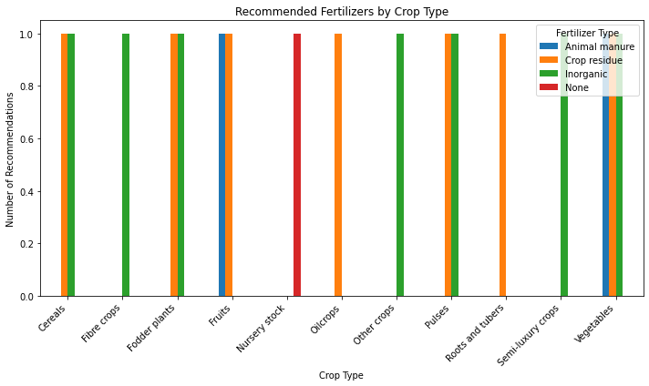

```python
# Illustrating the findings above on a bargraph
# Multi-label recommendations)
data = [
    ("Cereals", "Crop residue"),
    ("Cereals", "Inorganic"),

    ("Fibre crops", "Inorganic"),

    ("Fodder plants", "Crop residue"),
    ("Fodder plants", "Inorganic"),

    ("Fruits", "Crop residue"),
    ("Fruits", "Animal manure"),

    ("Nursery stock", "None"),

    ("Oilcrops", "Crop residue"),

    ("Other crops", "Inorganic"),

    ("Pulses", "Crop residue"),
    ("Pulses", "Inorganic"),

    ("Roots and tubers", "Crop residue"),

    ("Semi-luxury crops", "Inorganic"),

    ("Vegetables", "Crop residue"),
    ("Vegetables", "Animal manure"),
    ("Vegetables", "Inorganic"),
]

df = pd.DataFrame(data, columns=["crop_type", "fertilizer"])

# Create cross-tab (crop types as rows, fertilizers as columns)
ctab = pd.crosstab(df["crop_type"], df["fertilizer"])

# Plot grouped bar chart
ctab.plot(kind="bar", figsize=(10,6))

plt.title("Recommended Fertilizers by Crop Type")
plt.xlabel("Crop Type")
plt.ylabel("Number of Recommendations")
plt.xticks(rotation=45, ha="right")

plt.legend(title="Fertilizer Type", loc = 'upper right')
plt.tight_layout()

plt.show()
```

# 6.0 Modelling

In this section, we shall develop two models to predict crop type based on:

1. Physical soil attributes.
2. Soil Images
- We shall only use the physical soil attributes as our features in the first model and soil images as our feature in the second model. In both, crop type will be our target.
- The models will include Decision Trees, Random Forest classifier and Neural Networks.
- For each of the models above, we will first develop a model with base hyper parameters, then develop a model with tuned hyper parameters.
- We will then test each model on the training and testing data sets to determine over or under fitting.

## Why select the 2 models?

### Benefits of Decision Tree

- Decision trees can directly predict multiple classes without needing to transform the problem.
- Decision trees can model complex, non-linear relationships between features and classes.
- Trees can focus on splitting to maximize information gain for each class, making them robust.
- One can tune several hyper parameters such as tree depth, min samples per leaf, etc., to control complexity and reduce overfitting in multiclass problems.

### Benefits of Random Forest Classifier

- By averaging the multiple trees, Random Forest Classifier reduces errors and overfitting from individual models.
- It also handles large and omplex data better.
- It is robust to noise and outliers.
- Captures broader patterns that apply better to unseen data.

## 6.1 Model on physical soil attributes vs. crop type

```python
# Defining our X (features) and y (target)
X = phyc_soil_df
y = soil_df["crop_type"]

# One Hot Encoding X features and y target
X = pd.get_dummies(X, drop_first=True)
y = pd.get_dummies(y, drop_first=True)

# Force numeric types
X = X.apply(pd.to_numeric, errors="coerce")

# Splitting into training and test set
X_train, X_test, y_train, y_test = train_test_split(
    X, y,
    test_size=0.2,
    random_state=42,
    stratify=y
)
```

```python
# Developing pipelines for base Decision Trees (dt) and base Random Forest Classifier (rf)
pipelines = {
    "dt": Pipeline([
        ("model", DecisionTreeClassifier(
            random_state=42
        ))
    ]),

    "rf": Pipeline([
        ("model", RandomForestClassifier(
            random_state=42
        ))
    ])
}
```

```python
# Printing our accuracy scores for both base random forest and base xg boost
base_results = {}

for name, pipe in pipelines.items():

    # Fit model
    pipe.fit(X_train, y_train)

    # Predictions
    y_train_pred = pipe.predict(X_train)
    y_test_pred = pipe.predict(X_test)

    # Accuracy scores
    train_acc = accuracy_score(y_train, y_train_pred)
    test_acc = accuracy_score(y_test, y_test_pred)

    base_results[name] = {
        "train_accuracy": train_acc,
        "test_accuracy": test_acc
    }

    # Output
    print(f"\n {name.upper()}")
    print(f"Train Accuracy: {train_acc:.4f}")
    print(f"Test Accuracy:  {test_acc:.4f}")
```

```
 DT
Train Accuracy: 0.9448
Test Accuracy:  0.5830

 RF
Train Accuracy: 0.9473
Test Accuracy:  0.6397
```

#### Base model results interpretation

- DT: Train Accuracy: 0.9448 Test Accuracy: 0.5830
- RF: Train Accuracy: 0.9473 Test Accuracy: 0.6397

```python
# Creating base DT and base RF training and testing accuracy variables for plotting

DT_train_accuracy = base_results["dt"]["train_accuracy"]
DT_test_accuracy  = base_results["dt"]["test_accuracy"]

RF_train_accuracy = base_results["rf"]["train_accuracy"]
RF_test_accuracy  = base_results["rf"]["test_accuracy"]
```

```python
# In an attempt to improve the test accuracy of the Decision Trees and Random Forest Classifiers, we will attempt to run the same models but with hyper parameter tuning.
# Saving hyper parameters as param_grids
# Note that, to address class imbalance we added 'model_class_weight' into our hyperparameters.
param_grids = {
    "dt": {
        "model__max_depth": [None, 5, 10, 20],
        "model__min_samples_split": [2, 5, 10],
        "model__min_samples_leaf": [1, 2, 4],
        "model__criterion": ["gini", "entropy", "log_loss"],
        "model__class_weight": [None, "balanced"]
    },

    "rf": {
        "model__n_estimators": [100, 200, 500],
        "model__max_depth": [None, 10, 20, 30],
        "model__min_samples_split": [2, 5, 10],
        "model__min_samples_leaf": [1, 2, 4],
        "model__max_features": ["sqrt", "log2", None],
        "model__class_weight": [None, "balanced", "balanced_subsample"]
    }
}
```

```python
# Displaying the results after hyper parameter tuning

print("\n TUNED MODELS\n")

best_models = {}
tuned_results = {}

for name, pipeline in pipelines.items():

    print(f"\nTuning {name.upper()}...\n")

    search = RandomizedSearchCV(
        estimator=pipeline,
        param_distributions=param_grids[name],
        n_iter=20,
        cv=5,
        scoring="accuracy",
        n_jobs=-1,
        random_state=42,
        verbose=1
    )

    search.fit(X_train, y_train)

    best_models[name] = search.best_estimator_

    # Predictions
    y_train_pred = search.predict(X_train)
    y_test_pred = search.predict(X_test)

    # Accuracy
    train_acc = accuracy_score(y_train, y_train_pred)
    test_acc = accuracy_score(y_test, y_test_pred)

    # Tuned results
    tuned_results[name] = {
        "train_accuracy": train_acc,
        "test_accuracy": test_acc
    }

    print(f"\n{name.upper()} BEST PARAMS:")
    print(search.best_params_)

    print(f"{name.upper()} Training Accuracy: {train_acc:.4f}")
    print(f"{name.upper()} Test Accuracy: {test_acc:.4f}")
```

```
 TUNED MODELS


Tuning DT...

Fitting 5 folds for each of 20 candidates, totalling 100 fits

DT BEST PARAMS:
{'model__min_samples_split': 2, 'model__min_samples_leaf': 1, 'model__max_depth': 5, 'model__criterion': 'gini', 'model__class_weight': None}
DT Training Accuracy: 0.6650
DT Test Accuracy: 0.6457

Tuning RF...

Fitting 5 folds for each of 20 candidates, totalling 100 fits

RF BEST PARAMS:
{'model__n_estimators': 200, 'model__min_samples_split': 2, 'model__min_samples_leaf': 2, 'model__max_features': None, 'model__max_depth': 30, 'model__class_weight': None}
RF Training Accuracy: 0.7760
RF Test Accuracy: 0.6538
```

```python
# Creating tuned DT and tuned RF training and testing variables for plotting

DT_tuned_train_accuracy = tuned_results["dt"]["train_accuracy"]
DT_tuned_test_accuracy  = tuned_results["dt"]["test_accuracy"]

RF_tuned_train_accuracy = tuned_results["rf"]["train_accuracy"]
RF_tuned_test_accuracy  = tuned_results["rf"]["test_accuracy"]
```

Following the hyper parameter tuning, accuracy of the training and test set is closer to each other but still low to be definitive. We shall therefore try neural networks.

#### Benefits of a Neural Network

Neural networks are a type of machine learning model made of interconnected layers of nodes that learn patterns from data to make decisions.

When compared to the Random Forest Classifier, they:

- Are better for complex patterns.
- Scale better with large data.
- Provide more tools for overfitting such as regularization, dropout and early stopping.
- Handles underfitting with more flexibility by adding more layers (depth) and neurons (width).

For our Neural Network a standard full connected dense neural network was used. This is because the data is tabular, not spatial, and Dense layers are specifically designed to learn patterns in that kind of structured data. This is the architectural design:

```python
# Setting up a random seed.

np.random.seed(42)

# Convert one-hot labels to integers
y_integers = np.argmax(y_train.values, axis=1)
# ---- Compute class weights (balanced) ----
classes = np.unique(y_integers)
class_weights = compute_class_weight(
    class_weight="balanced",
    classes=classes,
    y=y_integers
)

class_weights = dict(zip(classes, class_weights))
model= keras.Sequential([
    # Inputs
    keras.Input(shape=(X_train.shape[1],), name= "inputs"),

    # Hidden layer 1
    layers.Dense(128, name="Dense_1"),
    layers.BatchNormalization(name="Batch_1"),
    layers.Activation('relu', name="relu_1"),
    layers.Dropout(0.3),

    # Hidden layer 2
    layers.Dense(64, name="Dense_2"),
    layers.BatchNormalization(name="Batch_2"),
    layers.Activation('relu', name="relu_2"),
    layers.Dropout(0.3),

    # Output layer
    layers.Dense(y_train.shape[1], name="Output", activation='softmax')
], name="Numbers_Classification")

# Compile
model.compile(
    loss="categorical_crossentropy",
    optimizer=keras.optimizers.Adam(),
    metrics=["accuracy"]
)

# Train
model.fit(
    X_train,
    y_train,
    epochs=100,
    batch_size=32,
    validation_split=0.15,
    class_weight=class_weights
)
```

```
<tensorflow.python.keras.callbacks.History at 0x1a7095e8460>
```

For this project, the dense neural network is not reliable model to use with this dataset because our dataset is structured or tabular which is best for Decision Trees and Random Forest Classifier.

- They handle nonlinear splits directly
- No need for scaling
- Work well with mixed feature distributions
- Require less data to generalize

```python
# Creating Neural Network Training and Testing variables for plotting

# Evaluate Neural Network
nn_train_loss, nn_train_accuracy = model.evaluate(X_train, y_train, verbose=0)
nn_test_loss, nn_test_accuracy   = model.evaluate(X_test, y_test, verbose=0)

# Rename variables
NN_train_accuracy = nn_train_accuracy
NN_test_accuracy  = nn_test_accuracy
```

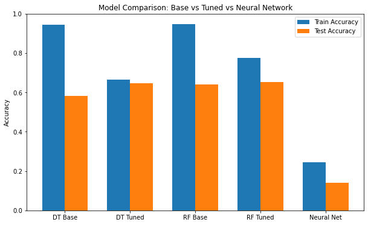

```python
# Illustrating the results of different algorithms, base and tuned using a bar chart

# Model names
models = [
    "DT Base",
    "DT Tuned",
    "RF Base",
    "RF Tuned",
    "Neural Net"
]

# Train accuracies
train_acc = [
    DT_train_accuracy,
    DT_tuned_train_accuracy,
    RF_train_accuracy,
    RF_tuned_train_accuracy,
    NN_train_accuracy
]

# Test accuracies
test_acc = [
    DT_test_accuracy,
    DT_tuned_test_accuracy,
    RF_test_accuracy,
    RF_tuned_test_accuracy,
    NN_test_accuracy
]

# Plot setup
x = np.arange(len(models))
width = 0.35

plt.figure(figsize=(10,6))

plt.bar(x - width/2, train_acc, width, label="Train Accuracy")
plt.bar(x + width/2, test_acc, width, label="Test Accuracy")

plt.xticks(x, models)
plt.ylabel("Accuracy")
plt.title("Model Comparison: Base vs Tuned vs Neural Network")
plt.ylim(0, 1)
plt.legend()
plt.show()
```

### 6.2 Model on soil Image Classifier as predictor for crop type

- For this model we will be using the soil_photos_array and crop_type of purely Kenyan data.
- We will be using the neural networks to create our model.

```python
# Rechecking our merged_physical_and_images_df

merged_physical_and_images_df.info()
```

```
<class 'pandas.core.frame.DataFrame'>
Int64Index: 87 entries, 0 to 86
Data columns (total 38 columns):
 #   Column                       Non-Null Count  Dtype
---  ------                       --------------  -----
 0   plot_code                    87 non-null     object
 1   image_array                  87 non-null     object
 2   country_code                 87 non-null     object
 3   survey_date                  87 non-null     object
 4   altitude                     87 non-null     int64
 5   longitude                    87 non-null     float64
 6   latitude                     87 non-null     float64
 7   tsu_id                       87 non-null     int64
 8   plot_id                      87 non-null     int64
 9   country_name                 87 non-null     object
```

[output cut: 30 more lines]

```python
# To run our neural network we need to convert our images_arrays from object back to numpy and normalize the values

X_images = np.stack(merged_physical_and_images_df["image_array"].values).astype("float32") / 255.0

# Checking the data type of image_arrays

type(X_images)
```

```
numpy.ndarray
```

```python
# Define x and y variables (One Hot Encode the y variable)
X = X_images

y = pd.get_dummies(merged_physical_and_images_df["crop_type"])
```

```python
# Spliting into training and testing data sets
X_train, X_test, y_train, y_test = train_test_split(X, y, test_size=0.2, random_state=42)
```

For this neural network, a CNN (Convolutional Neural Network) was used. A Convolutional Neural Network (CNN) is used for images because it is specifically designed to understand spatial structure in visual data, which traditional models (like Decision Trees, Random Forests, or even standard dense neural networks) cannot do well. This is the architectural design:

```python
# Convert one-hot labels to integers
y_integers = np.argmax(y_train.values, axis=1)

# Compute class weights (balanced)
classes = np.unique(y_integers)

class_weights = compute_class_weight(
    class_weight="balanced",
    classes=classes,
    y=y_integers
)

class_weights = dict(zip(classes, class_weights))

model = keras.Sequential([
    keras.Input(shape=X_train.shape[1:]),  # (H, W, C)

    layers.Conv2D(32, (3,3), activation="relu"),
    layers.MaxPooling2D(),

    layers.Conv2D(64, (3,3), activation="relu"),
    layers.MaxPooling2D(),

    layers.Flatten(),
    layers.Dense(128, activation="relu"),
    layers.Dropout(0.3),

    layers.Dense(y.shape[1], activation="softmax")
])

model.compile(
    optimizer="adam",
    loss="categorical_crossentropy",
    metrics=["accuracy"]
)

model.fit(X_train, y_train, epochs=20, batch_size=32, validation_split=0.15, class_weight=class_weights)
```

```
<tensorflow.python.keras.callbacks.History at 0x1a756c504c0>
```

- We would like to compare this to a neural network that has been trained with more features (soil images + physical soil attributes) to determine performance.

# 7.0 Recommendations

Almost all crops in this dataset require the exact same physical soil attributes: Cultivated land with no erosion, no surface salt, no surface crust, and no bare soil.

Despite these suggestions, recall that crop growth is dependent on more than 1 physical attribute. We therefore advise for the use of the aforementioned developed models to predict crop type.

Concerning fertilizer options, given what farmers are using, consider the following recommendations based on observed usage.

- **Cereals:** Use **crop residue or inorganic fertilizer**, as both are commonly applied with crop residue slightly leading.
- **Fibre crops:** Use **inorganic fertilizer**, which is the most widely used option for these crops.
- **Fodder plants:** Use **crop residue or inorganic fertilizer**, as they are equally the most common choices.
- **Fruits:** Use **crop residue**, with moderate support from animal manure as a secondary option.
- **Nursery stock:** No clear fertilizer recommendation, as none are currently used in the data.
- **Oilcrops:** Use **crop residue**, which is the most preferred fertilizer by a clear margin.
- **Other crops (e.g., rubber):** Use **inorganic fertilizer**, though overall fertilizer use is generally low.
- **Pulses:** Use **crop residue**, with inorganic fertilizer as a secondary option.
- **Roots and tubers:** Use **crop residue**, which is the most commonly applied input.
- **Semi-luxury crops (coffee, tea, cocoa, etc.):** Use **inorganic fertilizer**, the most dominant choice.
- **Vegetables:** Use a **combination of crop residue, animal manure, and inorganic fertilizer**, as all are equally important.

# 8.0 Limitations

These are the limitations we encountered:

# 9.0 Future Suggestions

We advise on:

1. Expanding the dataset by collecting a larger and more diverse set of soil images across multiple African countries, different climatic zones, seasons, and farming conditions to improve model generalisation, reduce bias, and enhance real-world performance.
2. Developing multimodal fusion models that combine soil images, physical soil attributes, and weather and climate data, crop yield and health to improve prediction accuracy and produce more robust and context-aware recommendations.

# 10.0 Model Export for Deployment

```python
# Create models directory if it doesn't exist
os.makedirs('models', exist_ok=True)
print("✓ Created 'models' directory")
```

```
✓ Created 'models' directory
```

```python
# Save Random Forest model (best for physical attributes)
rf_model = best_models["rf"]
joblib.dump(rf_model, 'models/random_forest_physical.pkl')
print("✓ Saved Random Forest model → models/random_forest_physical.pkl")
```

```
✓ Saved Random Forest model → models/random_forest_physical.pkl
```

```python
# Save CNN model (best for soil images)
model.save('models/cnn_image_classifier.h5')
print("✓ Saved CNN model → models/cnn_image_classifier.h5")
```

```
✓ Saved CNN model → models/cnn_image_classifier.h5
```

```python
# Save physical features list (for API to know expected input format)
# Extract feature names from the Random Forest model or phyc_soil_df
try:
    # Try to get from model if available
    if hasattr(rf_model.named_steps['model'], 'feature_names_in_'):
        physical_features = rf_model.named_steps['model'].feature_names_in_.tolist()
    else:
        # Get from one-hot encoded features - we'll extract from phyc_soil_df
        X_encoded = pd.get_dummies(phyc_soil_df, drop_first=True)
        physical_features = X_encoded.columns.tolist()
except:
    # Fallback: manually list common features from the physical soil data
    physical_features = list(phyc_soil_df.columns)

joblib.dump(physical_features, 'models/physical_features.pkl')
print(f"✓ Saved {len(physical_features)} physical features → models/physical_features.pkl")
```

```
✓ Saved 36 physical features → models/physical_features.pkl
```

```python
# Save crop types (for API to map predictions to crop names)
# Get unique crop types from merged Kenyan dataset
crop_types = sorted(merged_physical_and_images_df["crop_type"].unique().tolist())
joblib.dump(crop_types, 'models/crop_types.pkl')
print(f"✓ Saved {len(crop_types)} crop types → models/crop_types.pkl")
print(f"  Crops: {crop_types}")
```

```
✓ Saved 8 crop types → models/crop_types.pkl
  Crops: ['Cereals', 'Fodder plants', 'Fruits', 'Other crops (e.g., rubber)', 'Pulses', 'Roots and tubers', 'Semi-luxury foods (coffee, tea, cocoa, tobacco, nuts)', 'Vegetables']
```

```python
# Verify all files were created
model_files = os.listdir('models')
print("ALL MODELS EXPORTED SUCCESSFULLY")
for file in sorted(model_files):
    file_size = os.path.getsize(f'models/{file}') / 1024 / 1024  # Convert to MB
    print(f"  {file} ({file_size:.2f} MB)")
```

```
ALL MODELS EXPORTED SUCCESSFULLY
  cnn_image_classifier.h5 (273.65 MB)
  crop_types.pkl (0.00 MB)
  dnn_physical.h5 (273.65 MB)
  physical_features.pkl (0.00 MB)
  random_forest_physical.pkl (30.26 MB)
```